# Internações (SIH-RD)

Dois sabores (principal vs qualquer campo) · peso das MPS/TRE · permanência · 2010–2025

79.401

AIH com EIM principal

448.345

AIH com EIM em qualquer campo

1,0 dias

permanência mediana (principal)

R$ 56.599.562

gasto hospitalar (principal)

A internação por EIM captura **descompensações agudas** e, sobretudo, os **procedimentos de alto custo** (infusões de **terapia de reposição enzimática — TRE** das mucopolissacaridoses e outras doenças de depósito). O SIH tem **dois sabores** que **não devem ser somados** nem entre si nem com o SIA:

- **Diagnóstico principal** (`diag_princ`): a EIM foi o **motivo** da internação — leitura conservadora, 79.401 AIH.
- **Qualquer campo** (principal + secundários `diagsec1–9`): a EIM aparece em **qualquer posição** — 448.345 AIH, teto que inclui comorbidade/contexto.

## Os dois sabores

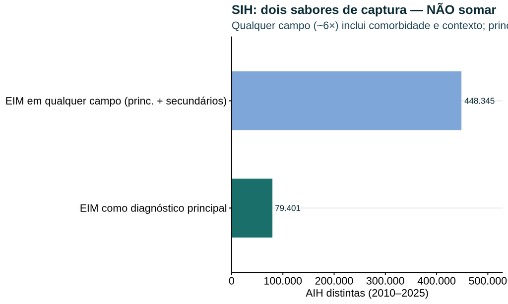

| camada_qualquer | aih_registros |
| --- | --- |
| envelope | 254,334 |
| limitrofe | 108,603 |
| core | 85,640 |

Só 'core' é achado epidemiológico primário; o resto é teto de subcodificação, triagem fora do capítulo E ou fora de escopo analítico.

## Peso das mucopolissacaridoses (MPS) e demais traçadoras

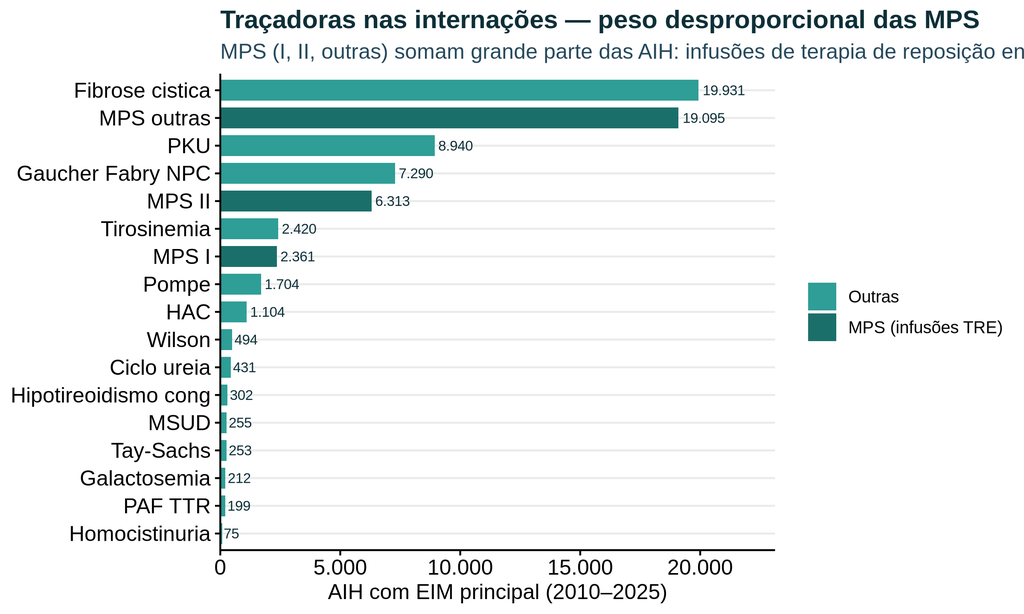

**MPS = internações recorrentes de TRE.** As mucopolissacaridoses têm peso hospitalar desproporcional ao seu número de pacientes porque cada paciente gera **múltiplas AIH de infusão** (terapia de reposição enzimática periódica) — o volume de AIH mede **intensidade de tratamento**, não número de indivíduos.

## Tendência de internação padronizada

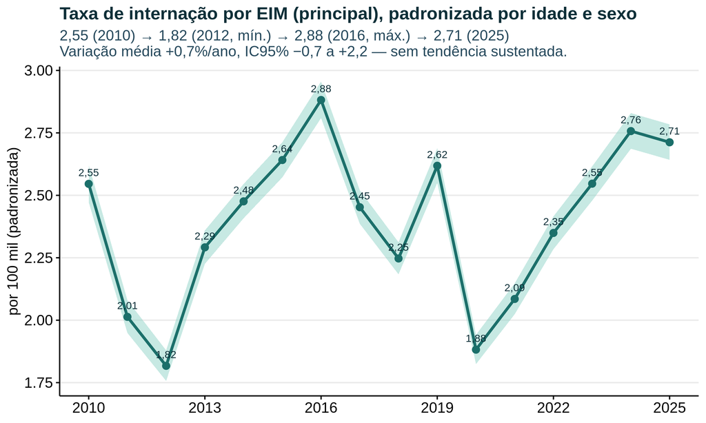

Na série 2010–2025, a internação por EIM (diagnóstico principal) está **sem tendência sustentada** (+0,7%/ano, IC95% −0,7 a +2,2; sem 2020–2022, +1,3%/ano, IC95% −0,1 a +2,6): oscila entre 1,82 e 2,88 por 100 mil (2,55 (2010) → 1,82 (2012, mín.) → 2,88 (2016, máx.) → 2,71 (2025)). O vale de 2020 (−28,1% em relação a 2019) é a **pandemia**, e a retomada a partir de 2021 é sobretudo **recuperação** desse vale — num recorte curto que começa em 2021 ela parece uma “alta clara”, que a série longa desfaz. Como o volume hospitalar é dominado pelas **infusões de TRE** (MPS, esfingolipidoses), a série mede uso de serviço, não incidência.

## Estrutura etária e por sexo das internações

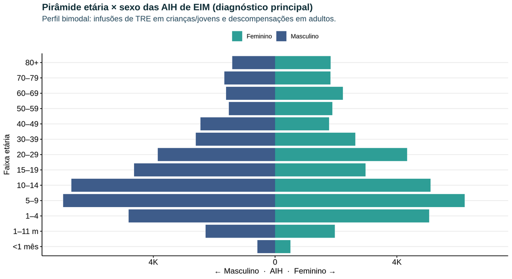

## Permanência hospitalar

[figure not shown]

## Uso de UTI e tempo de internação

O SIH permite distinguir a **internação de infusão** (hospital-dia, curta, sem UTI) da **descompensação grave** (com UTI). Usamos `MARCA_UTI` (≠ “00” = usou UTI) e `UTI_MES_TO` (nº de diárias de UTI); `DIAS_PERM` é a permanência total. O termo **TRE** (terapia de reposição enzimática) está no Glossário.

3,7%

das AIH-EIM (principal) usaram UTI

2.928

AIH-EIM com passagem por UTI

1,0 dias

permanência total mediana

5,0 diárias

UTI mediana (entre quem usou)

| Traçadora | AIH | AIH c/ UTI | % com UTI | Perm. mediana (dias) | UTI mediana (diárias, entre quem usou) |
| --- | --- | --- | --- | --- | --- |
| Ciclo ureia | 431 | 64 | 14,8 | 4,0 | 4,5 |
| MSUD | 255 | 35 | 13,7 | 5,0 | 8,0 |
| HAC | 1.104 | 136 | 12,3 | 5,0 | 4,0 |
| Hipotireoidismo cong | 302 | 34 | 11,3 | 5,0 | 7,0 |
| Homocistinuria | 75 | 7 | 9,3 | 4,0 | 2,0 |
| Fibrose cistica | 19.931 | 1.644 | 8,2 | 12,0 | 5,0 |
| Galactosemia | 212 | 17 | 8,0 | 6,5 | 5,0 |
| Wilson | 494 | 36 | 7,3 | 4,0 | 5,5 |
| Pompe | 1.704 | 120 | 7,0 | 1,0 | 9,0 |
| Tay-Sachs | 253 | 12 | 4,7 | 2,0 | 6,0 |
| Tirosinemia | 2.420 | 108 | 4,5 | 3,0 | 3,0 |
| PAF TTR | 199 | 6 | 3,0 | 1,0 | 1,5 |
| PKU | 8.940 | 226 | 2,5 | 3,0 | 3,0 |
| Gaucher Fabry NPC | 7.290 | 28 | 0,4 | 0,0 | 12,0 |
| MPS II | 6.313 | 11 | 0,2 | 0,0 | 2,0 |
| MPS outras | 19.095 | 20 | 0,1 | 0,0 | 1,0 |

Ordenado por % de AIH com UTI. UTI = MARCA_UTI ≠ '00'. Diárias de UTI medianas calculadas entre AIH que usaram UTI. Supressão N<5. Traçadoras com AIH-UTI < 5 têm % suprimido.

## Onde as internações se concentram — taxa padronizada por UF

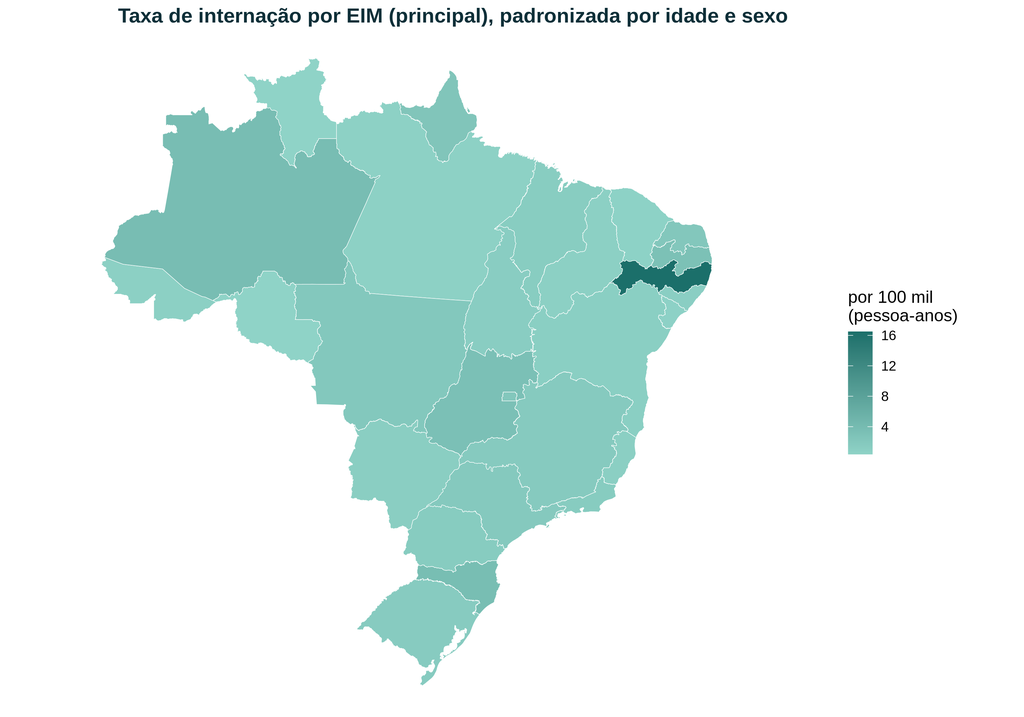

## Limitações

- **Dois sabores não somáveis** e não somáveis com o SIA; cada AIH é um evento de internação, **não uma pessoa** (TRE gera múltiplas AIH por paciente/ano).
- Detecção/uso, **não prevalência**; variação por UF reflete acesso e rede de referência.
- N baixo em traçadoras raras → taxas instáveis; supressão de N<5 nas taxas divulgadas.